# Introduction to fhimaps

Richard Aubrey White, Chi Zhang

2021-01-15

`fhimaps` is a package for map visualisation developed by researchers at Norwegian Institute of Public Health (Folkehelseinstituttet, FHI). The package contains map data for Norway at different levels geographic granularity and layout.

| name | scope | geographic_granularity | type | border | layout | R class |
| --- | --- | --- | --- | --- | --- | --- |
| norway_lau2_map_b2019_default_dt | norway | lau2 | map | 2019 | default | data.table |
| norway_lau2_map_b2019_default_sf | norway | lau2 | map | 2019 | default | sf |
| norway_lau2_map_b2019_insert_oslo_dt | norway | lau2 | map | 2019 | insert_oslo | data.table |
| norway_lau2_map_b2020_default_dt | norway | lau2 | map | 2020 | default | data.table |
| norway_lau2_map_b2020_default_sf | norway | lau2 | map | 2020 | default | sf |
| norway_lau2_map_b2020_insert_oslo_dt | norway | lau2 | map | 2020 | insert_oslo | data.table |
| norway_lau2_map_b2020_split_dt | norway | lau2 | map | 2020 | split | data.table |
| norway_nuts3_map_b2017_default_dt | norway | nuts3 | map | 2017 | default | data.table |
| norway_nuts3_map_b2017_default_sf | norway | nuts3 | map | 2017 | default | sf |
| norway_nuts3_map_b2017_insert_oslo_dt | norway | nuts3 | map | 2017 | insert_oslo | data.table |
| norway_nuts3_map_b2019_default_dt | norway | nuts3 | map | 2019 | default | data.table |
| norway_nuts3_map_b2019_default_sf | norway | nuts3 | map | 2019 | default | sf |
| norway_nuts3_map_b2019_insert_oslo_dt | norway | nuts3 | map | 2019 | insert_oslo | data.table |
| norway_nuts3_map_b2020_default_dt | norway | nuts3 | map | 2020 | default | data.table |
| norway_nuts3_map_b2020_default_sf | norway | nuts3 | map | 2020 | default | sf |
| norway_nuts3_map_b2020_insert_oslo_dt | norway | nuts3 | map | 2020 | insert_oslo | data.table |
| norway_nuts3_map_b2020_split_oslo_dt | norway | nuts3 | map | 2020 | split | data.table |
| norway_nuts3_position_geolabels_b2017_default_dt | norway | nuts3 | position_geolabels | 2017 | default | data.table |
| norway_nuts3_position_geolabels_b2019_default_dt | norway | nuts3 | position_geolabels | 2019 | default | data.table |
| norway_nuts3_position_geolabels_b2020_default_dt | norway | nuts3 | position_geolabels | 2020 | default | data.table |
| norway_nuts3_position_geolabels_b2020_insert_oslo_dt | norway | nuts3 | position_geolabels | 2020 | insert_oslo | data.table |
| norway_lau2_position_geolabels_b2020_default_dt | norway | lau2 | position_geolabels | 2020 | default | data.table |
| norway_lau2_position_geolabels_b2020_insert_oslo_dt | norway | lau2 | position_geolabels | 2020 | insert_oslo | data.table |
| norway_xxx_position_title_insert_oslo_b2017_insert_oslo_dt | norway | xxx | position_title_insert_oslo | 2017 | insert_oslo | data.table |
| norway_xxx_position_title_insert_oslo_b2019_insert_oslo_dt | norway | xxx | position_title_insert_oslo | 2019 | insert_oslo | data.table |
| norway_xxx_position_title_insert_oslo_b2020_insert_oslo_dt | norway | xxx | position_title_insert_oslo | 2020 | insert_oslo | data.table |
| oslo_ward_map_b2020_default_dt | oslo | ward | map | 2020 | default | data.table |
| oslo_ward_map_b2020_default_sf | oslo | ward | map | 2020 | default | sf |
| oslo_ward_position_geolabels_b2020_default_dt | oslo | ward | position_geolabels | 2020 | default | data.table |

## Naming scheme

The naming scheme has the following pattern: `scope_geogranularity_type_border_layout_Rclass`.

#### Scope

This is what content the map data contains. Currently we focus on these 2 scopes:

- country (Norway)
- city (Oslo)

#### Geogranularity

This is the geographic granularity, which defines the border of county, municipality and ward. We follow the EU definition of territorial unit ([NUTS](https://ec.europa.eu/eurostat/web/nuts/nuts-maps), [LAU](https://ec.europa.eu/eurostat/web/nuts/local-administrative-units)) when applicable.

- [NUTS3](https://ec.europa.eu/eurostat/documents/345175/7451602/2021-NUTS-3-map-NO.pdf): Nomenclature of Territorial Unit level 3. Equivalent to fylke (county) in Norway.
- LAU2: Local Administrative Unit level 2. Equivalent to kommune (municipality) in Norway.
- ward: district within a municipality. Bydel in Norwegian. So far we only have the data for Oslo.
- xxx: only used for plotting `position_title`. (see example)

#### Type

The type of the data object to distinguish whether it’s a geographical map or coordinate for label positions.

- map: map data, in either `data.table` or `sf` class.
- position geolabels: geographical coordinates for the position of labels, e.g. “county03” or “Oslo”.
- position title (insert oslo): geographical coordinate for position of title. So far it’s only for layout: `insert_oslo`. (see example)

#### Border

Due to recent redistricting, there exist multiple versions of county borders. We provide maps that match the borders in the following years:

- 2020: the current border, this map contains 11 counties.
- 2019: border before redistricting in 2020. This map contains 19 counties.
- 2017: border before redistricting in 2018.

More information on counties in Norway can be found [here](https://en.wikipedia.org/wiki/Counties_of_Norway#cite_note-13).

#### Layout

Map layout, see this section for examples.

#### R class

R class for the map object.

- `data.table`: applicable for maps and label/title coordinates.
- `sf`: simple feature for spatial vector data. More on [sf](https://r-spatial.github.io/sf/articles/).

# Examples

This section provides examples on:

- Layout options
- Customization with color and label
- `sf` for interactive maps

#### Set up

```r
library(fhimaps)
```

```r
library(ggplot2)
library(data.table)
library(magrittr)
```

## Layout options

We have 3 layout options for Norway map: **default, split** and **insert Oslo**.

For Oslo county map, we only have the **default** layout.

### Norway layout: default

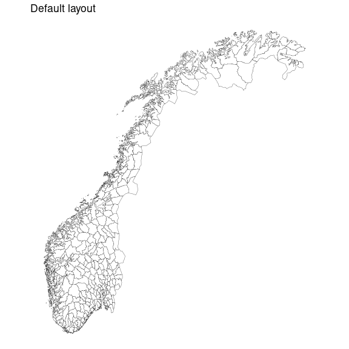

```r
pd <- copy(fhimaps::norway_lau2_map_b2020_default_dt)
q <- ggplot()
q <- q + geom_polygon(data = pd, aes( x = long, y = lat, group = group),
                      color="black", fill="white", size=0.1)
q <- q + theme_void()
q <- q + coord_quickmap()
q <- q + labs(title = "Default layout")
q
```

### Norway layout: split

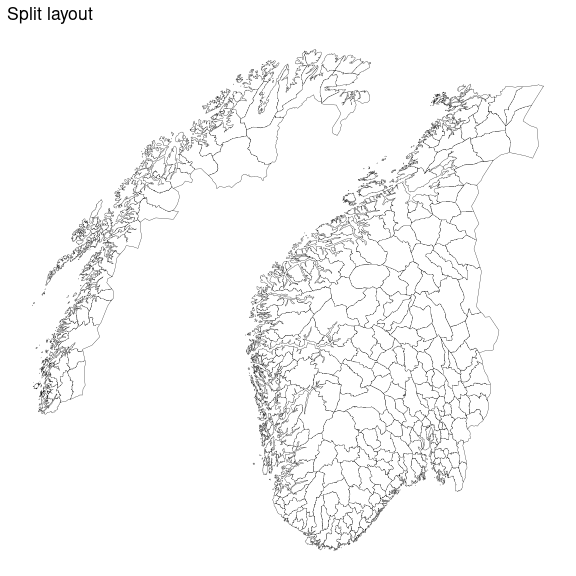

```r
pd <- copy(fhimaps::norway_lau2_map_b2020_split_dt)
q <- ggplot()
q <- q + geom_polygon(data = pd, aes( x = long, y = lat, group = group),
                      color="black", fill="white", size=0.1)
q <- q + theme_void()
q <- q + coord_quickmap()
q <- q + labs(title = "Split layout")
q
```

### Norway layout: insert oslo

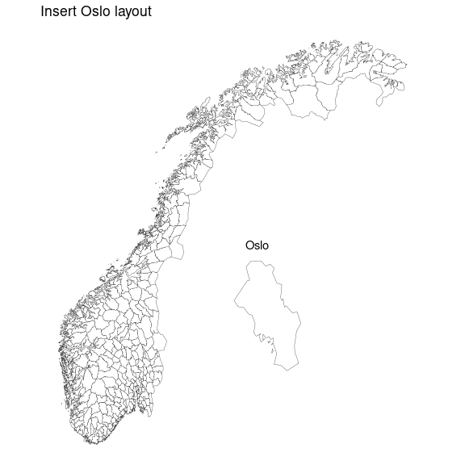

```r
pd <- copy(fhimaps::norway_lau2_map_b2020_insert_oslo_dt)
q <- ggplot()
q <- q + geom_polygon(data = pd, aes( x = long, y = lat, group = group),
                      color="black", fill="white", size=0.1)

# add title "Oslo"
q <- q + annotate(
  "text",
  x = fhimaps::norway_xxx_position_title_insert_oslo_b2020_insert_oslo_dt$long,
  y = fhimaps::norway_xxx_position_title_insert_oslo_b2020_insert_oslo_dt$lat,
  label = "Oslo"
  )
q <- q + theme_void()
q <- q + coord_quickmap()
q <- q + labs(title = "Insert Oslo layout")
q
```

#### Oslo ward layout: default

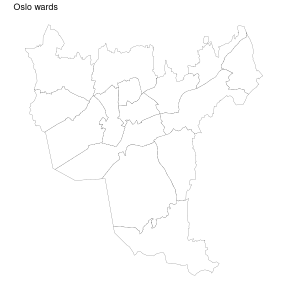

```r
pd <- copy(fhimaps::oslo_ward_map_b2020_default_dt)
q <- ggplot()
q <- q + geom_polygon(data = pd, aes(x = long, y = lat, group = group),
                      color="black", fill="white", size=0.1)
q <- q + theme_void()
q <- q + coord_quickmap()
q <- q + labs(title = "Oslo wards")
q
```

## Customise the maps

The maps can be easily customized with color and labels.

#### Automatic coloring by `location_code`

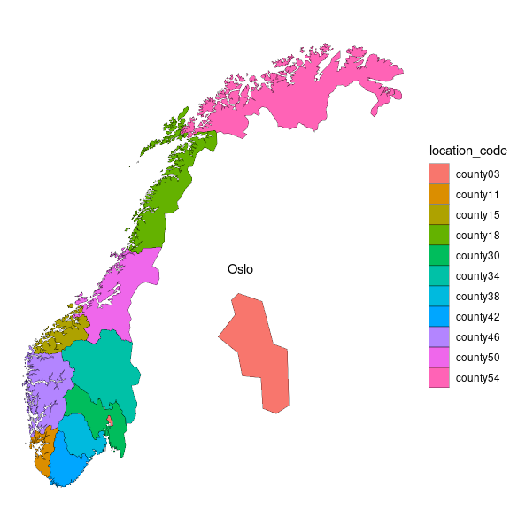

```r
pd <- copy(fhimaps::norway_nuts3_map_b2020_insert_oslo_dt)

q <- ggplot()
q <- q + geom_polygon(
  data = pd,
  mapping = aes(
    x = long,
    y = lat,
    group = group,
    fill = location_code
  ),
  color="black",
  size=0.1
)
q <- q + annotate(
  "text",
  x = fhimaps::norway_xxx_position_title_insert_oslo_b2020_insert_oslo_dt$long,
  y = fhimaps::norway_xxx_position_title_insert_oslo_b2020_insert_oslo_dt$lat,
  label = "Oslo"
)
q <- q + theme_void()
q <- q + coord_quickmap()
q <- q + labs(title = "")
q
```

#### Customized coloring with external information

It is also possible to specify the color by user-defined groups. Here we show an example of assigning different (pseudo) risk level to each county.

```r
pd <- copy(fhimaps::norway_nuts3_map_b2020_insert_oslo_dt)

# assign each location a random category for different colors
location_info <- unique(pd[,c("location_code")])
location_info[,category:=rep(
  c("Good","Normal","Neutral","Bad","Very Bad"),
  each=3)[1:.N]
]
location_info[,category:=factor(
  category,
  levels=c("Good","Normal","Neutral","Bad","Very Bad")
  )
]
print(location_info)
```

```
#>     location_code category
#>  1:      county11     Good
#>  2:      county15     Good
#>  3:      county18     Good
#>  4:      county03   Normal
#>  5:      county30   Normal
#>  6:      county34   Normal
#>  7:      county38  Neutral
#>  8:      county42  Neutral
#>  9:      county46  Neutral
#> 10:      county50      Bad
#> 11:      county54      Bad
```

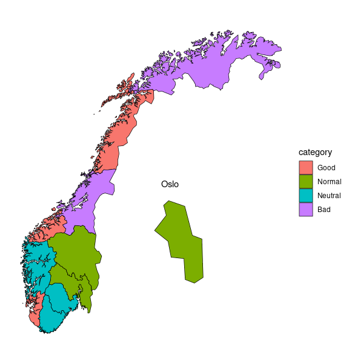

```r
# join the map data.table
pd[location_info,on="location_code",category:=category]

q <- ggplot()
q <- q + geom_polygon(
  data = pd,
  mapping = aes(
    x = long,
    y = lat,
    group = group,
    fill=category
  ),
  color="black",
  size=0.25
)
q <- q + annotate(
  "text",
  x = fhimaps::norway_xxx_position_title_insert_oslo_b2020_insert_oslo_dt$long,
  y = fhimaps::norway_xxx_position_title_insert_oslo_b2020_insert_oslo_dt$lat,
  label = "Oslo"
)
q <- q + coord_quickmap()
# it is possible to use the color palette provided in fhiplot
# q <- q + fhiplot::scale_fill_fhi("Category", palette = "map_seq_complete", direction = 1)
q <- q + labs(title="")
q <- q + theme_void()
q
```

### Add labels to each geographic unit

We can add labels of county index onto the maps. There are several options for adding texts on a graph in `ggplot2`. We recommend `geom_label()` to add the labels if no label overlap occurs, otherwise we recommend using `ggrepel::geom_label_repel()`.

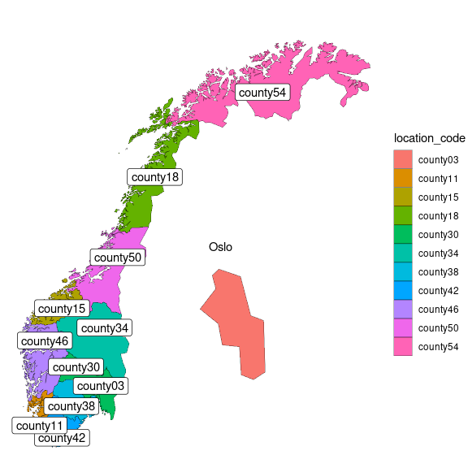

```r
pd <- copy(fhimaps::norway_nuts3_map_b2020_insert_oslo_dt)
q <- ggplot()
q <- q + geom_polygon(
  data = pd,
  mapping = aes(
    x = long,
    y = lat,
    group = group,
    fill = location_code
  ),
  color="black",
  size=0.1
)
q <- q + annotate(
  "text",
  x = fhimaps::norway_xxx_position_title_insert_oslo_b2020_insert_oslo_dt$long,
  y = fhimaps::norway_xxx_position_title_insert_oslo_b2020_insert_oslo_dt$lat,
  label = "Oslo"
)
q <- q + geom_label(
  data = fhimaps::norway_nuts3_position_geolabels_b2020_default_dt,
  mapping = aes(x = long, y = lat, label = location_code)
  )
# ggrepel::geom_label_repel() for avoiding overlap
q <- q + theme_void()
q <- q + coord_quickmap()
q <- q + labs(title = "")
q
```

Labels can be easily added to other layouts, such as Oslo wards.

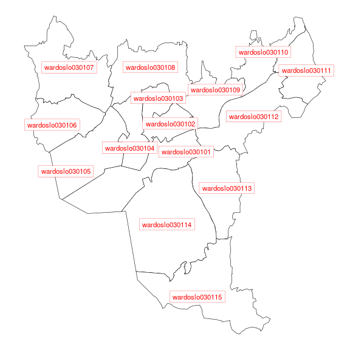

```r
q <- ggplot(mapping = aes(x = long, y = lat))
q <- q + geom_polygon(
  data = fhimaps::oslo_ward_map_b2020_default_dt,
  mapping = aes(group = group),
  color = "black",
  fill = "white",
  size = 0.2
)
q <- q + geom_label(
  data = fhimaps::oslo_ward_position_geolabels_b2020_default_dt,
  mapping = aes(label = location_code),
  color = "red",
  size = 3,
  label.size = 0.1,
  label.r = grid::unit(0, "lines")
)
q <- q + theme_void()
q <- q + coord_quickmap()
q
```

### enrich plot with additional data

It is convenient to use `fhidata` package to enrich Norway and Oslo maps with external information, such as location name and population. We illustrate how to do it here.

```r
# enrich with population and location name
dpop_2020 <- fhidata::norway_population_b2020[
  year == '2020',
  .(pop_total = sum(pop)),
  keyby = location_code
]

# join, create label
labels <- copy(fhimaps::norway_nuts3_position_geolabels_b2020_insert_oslo_dt)
labels[
  dpop_2020,
  on = "location_code",
  pop_total := pop_total
]
labels[
  fhidata::norway_locations_long_b2020,
  on = "location_code",
  location_name := location_name
]
labels[, label := paste0(location_name, '\n', pop_total)]
print(head(labels))
```

```
#>    location_code  long      lat pop_total        location_name
#> 1:      county30  8.85 60.60000   1241165                Viken
#> 2:      county03 20.85 62.00000    693494                 Oslo
#> 3:      county34 11.00 61.86886    371385            Innlandet
#> 4:      county38  8.50 59.32481    419396 Vestfold og Telemark
#> 5:      county42  7.80 58.30000    307231                Agder
#> 6:      county11  6.10 58.70000    479892             Rogaland
#>                           label
#> 1:               Viken\n1241165
#> 2:                 Oslo\n693494
#> 3:            Innlandet\n371385
#> 4: Vestfold og Telemark\n419396
#> 5:                Agder\n307231
#> 6:             Rogaland\n479892
```

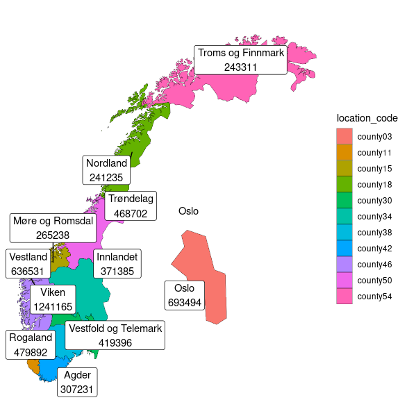

```r
# plot
pd <- copy(fhimaps::norway_nuts3_map_b2020_insert_oslo_dt)
q <- ggplot()
q <- q + geom_polygon(
  data = pd,
  mapping = aes(
    x = long,
    y = lat,
    group = group,
    fill = location_code
  ),
  color="black",
  size=0.1
)
q <- q + annotate(
  "text",
  x = fhimaps::norway_xxx_position_title_insert_oslo_b2020_insert_oslo_dt$long,
  y = fhimaps::norway_xxx_position_title_insert_oslo_b2020_insert_oslo_dt$lat,
  label = "Oslo"
)
q <- q + ggrepel::geom_label_repel(
  data = labels,
  mapping = aes(x = long, y = lat, label = label)
)
q <- q + theme_void()
q <- q + coord_quickmap()
q <- q + labs(title = "")
q
```

```r
# enrich with population and location name
dpop_2020 <- fhidata::norway_population_b2020[
  year == '2020',
  .(pop_total = sum(pop)),
  keyby = location_code
]

# join, create label
labels <- copy(fhimaps::oslo_ward_position_geolabels_b2020_default_dt)
labels[
  dpop_2020,
  on = "location_code",
  pop_total := pop_total
]
labels[
  fhidata::norway_locations_long_b2020,
  on = "location_code",
  location_name := location_name
]
labels[, label := paste0(location_name, '\n', pop_total)]
print(head(labels))
```

```
#>     location_code     long      lat pop_total  location_name
#> 1: wardoslo030101 10.79760 59.91010     58671     Gamle Oslo
#> 2: wardoslo030102 10.78000 59.92567     62423    Grünerløkka
#> 3: wardoslo030103 10.76683 59.93981     45089         Sagene
#> 4: wardoslo030104 10.73555 59.91230     38945 St. Hanshaugen
#> 5: wardoslo030105 10.66500 59.89925     59269        Frogner
#> 6: wardoslo030106 10.65000 59.92500     34569         Ullern
#>                    label
#> 1:     Gamle Oslo\n58671
#> 2:    Grünerløkka\n62423
#> 3:         Sagene\n45089
#> 4: St. Hanshaugen\n38945
#> 5:        Frogner\n59269
#> 6:         Ullern\n34569
```

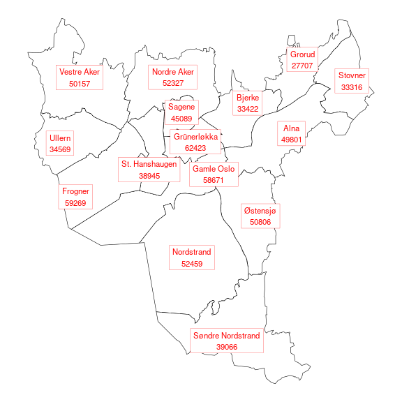

```r
q <- ggplot(mapping = aes(x = long, y = lat))
q <- q + geom_polygon(
  data = fhimaps::oslo_ward_map_b2020_default_dt,
  mapping = aes(group = group),
  color = "black",
  fill = "white",
  size = 0.2
)
q <- q + geom_label(
  data = labels,
  mapping = aes(label = label),
  color = "red",
  size = 3,
  label.size = 0.1,
  label.r = grid::unit(0, "lines")
)
q <- q + theme_void()
q <- q + coord_quickmap()
q
```

## `sf` for interactive maps

We provide the option of how to use `sf` class object to create interactive maps. It requres the `leaflet` package.

```r
pd_county <- fhimaps::norway_nuts3_map_b2019_default_sf
leaflet::leaflet(
  pd_county,
  options = leaflet::leafletOptions(preferCanvas = F)
) %>%
  leaflet::addProviderTiles(leaflet::providers$Esri.WorldGrayCanvas) %>%
  leaflet::addPolygons(
   #  fillColor = ~ pal_not_censored(n_0_13_fixed_status_with_numbers),
    weight = 0.3,
    opacity = 1,
    color = "black", fillColor = 'white',
    fillOpacity = 0.9  )
```

[interactive chart not shown]